# R Notebook

#### **Gini index**

```r
library(rpart)
library(rpart.plot)
cart_fit=rpart(will_go_to_college~., data=train_data, method="class",cp=0.008)

rpart.plot(cart_fit)

testPred<- predict(cart_fit,newdata=test_data,type="class")
results<- confusionMatrix(testPred,test_data$will_go_to_college,positive="1")
print(results)
```

[output not shown]

this matrix below show the evaluation model on testing data

[output not shown]

27% of the dataset follows the rule:

IF average_grades=+A,+B,A and parent_salary>=0.37 and house_area>=0.41 and type_school=1, THEN will_go_to_collage=0.

These rules highlight the complexity and variability in determining whether a student will go to college. Even if a student has stable financial circumstances and good grades, it does not guarantee their enrollment in college. in contract to the second which mean Other factors could play a role in the decision-making process.

we only mentioned those two rules duo to their high percentage of data

## final analysis

#### information gain

Information Gain is a measure used in the ID3 algorithm for attribute selection in decision tree learning. It quantifies the amount of information obtained about the class variable when a given attribute is used to split the data. The Information Gain is calculated by substract the entropy Expected information needed to classify a tuple in D a with Conditional Entropy Information needed after using A to split D into v partitions, to classify D . A higher Information Gain indicates that the attribute is more informative and should be chosen as the splitting criterion.

for our trees,

average grade was chosen as the root attribute for all 3 trees with the highest information gain This attribute Reflects the least randomness or “impurity” in these partitions and guarantees that a simple tree is found.

|  | 50%-50% | 70%-30% | 80%-20% |
| --- | --- | --- | --- |
| Accuracy | 84.22% | 82.37 % | 83.84 % |
| Error rate | 15.78% | 17.63% | 16.16% |
| Sensitivity | 89.53% | 75.89% | 86.73% |
| Specificity | 78.71% | 88.31% | 81.00% |
| Precision | 81.34% | 85.60% | 81.73% |

the evaluation method table shows that the best partiton for information gain shows that 50%-50% is the best model based on accuracy(tuples that are correctly classified) with precntages 84.22% and Sensitivity (True positive recognition rate) with 89.53% but the lowest Specificity(True negative recognition rate) with 78.71%. overall it’s the best model for information gain has the lowest error rate 15.78%

#### gain ratio

Gain Ratio is an normaliztion for Information Gain and is used in the C4.5 algorithm, which is an extension of ID3. While Information Gain tends to favor attributes with many multivariate It is calculated by dividing the Information Gain by SplitInfo a(D).

for our trees,

Parent salary was chosen as the root attribute for all 3 trees due to its high Gain ratio, the trees split are unbalanced since gain ratio Tends to prefer unbalanced splits in which one partition is much smaller than the others

|  | 50%-50% | 70%-30% | 80%-20% |
| --- | --- | --- | --- |
| Accuracy | 85.21% | 80.34% | 80.03% |
| Error rate | 14.79% | 19.66% | 19.97% |
| Sensitivity | 87.60% | 77.30% | 84.69% |
| Specificity | 82.73% | 83.12% | 76.00% |
| Precision | 84.01% | 80.74% | 77.57% |

#### gini index

Gini Index is a criterion used in the CART (Classification and Regression Trees) algorithm for attribute selection. It measures the impurity of a set of tuples, with lower values Gini a(D) indicating higher purity. The Gini Index is calculated by summing the squared probabilities of each class label in the set

for our trees,

gini index had different root (parent salary/house area/averages grades) for each tree

|  | 50%-50% | 70%-30% | 80%-20% |
| --- | --- | --- | --- |
| Accuracy | 85.21% | 79.66% | 80.81% |
| Error rate | 14.79% | 20.34% | 19.19% |
| Sensitivity | 88.37% | 78.01% | 76.53% |
| Specificity | 81.93% | 81.17% | 85.00% |
| Precision | 83.52% | 79.14% | 83.33% |

**noticeable notes**

parent’s salary was the root of 4 of 9 trees

average grades was the root of 4 of 9 trees

house area was the root only once 1 of 9 tree

In summary, the analysis of the decision trees reveals that financial circumstances, as indicated by parent’s salary, and academic performance, as indicated by average grades, are crucial factors for contemporary universities when predicting college enrollment. In this particular dataset, gender is not considered highly important in the decision-making process.

#### best model

the 50% training, 50% testing was the best partition for all attribute selection measures with accuracies 85.21%. for both gini index and gain ratio

Both attribute selection measures yield the same accuracy and error rate, so we need to check the remaining evaluation metrics that is provided:

|  | gain ratio | gini index |
| --- | --- | --- |
| Accuracy | 85.21% | 85.21% |
| Error rate | 14.79% | 14.79% |
| Sensitivity | 87.60% | 88.37% |
| Specificity | 82.73% | 81.93% |
| Precision | 84.01% | 83.52% |

Comparing the sensitivity, specificity, and precision:

- Sensitivity: Gini Index has a higher sensitivity value (88.37%) compared to Gain Ratio (87.60%). Higher sensitivity indicates a better ability to correctly identify positive instances so **gini index is better regarding Sensitivity.**

- Specificity: Gini Index has a lower specificity value (81.93%) compared to Gain Ratio (82.73%). Higher specificity indicates a better ability to correctly identify negative instances.

- Precision: Gain Ratio has a higher precision value (84.01%) compared to Gini Index (83.52%). Higher precision indicates a better ability to correctly classify positive instances.

**so gain ratio is better regarding** **Specificity and Precision .**

Based on these comparisons, it is difficult to determine definitively which attribute selection measure is the best. The choice between Gini Index and Gain Ratio may depend on the specific requirements and priorities of the problem but since we focus on the true positive more than true negative because our goal of classification to determine who will go to collage, so we will choose the model based on the sensitivity (Gini index)

our final tree is:

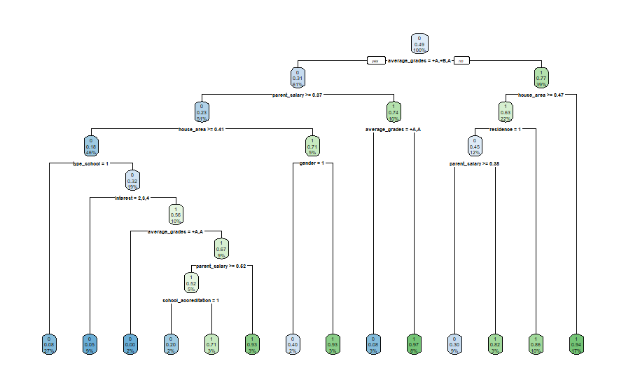

## Clustering **Analysis:**

In this analysis, we apply K-means clustering to the dataset using different values of K. K-means clustering is an unsupervised learning algorithm that partitions the data into K clusters based on similarity. We will explore three different values of K and evaluate the clustering results using various metrics.

### Removing the class label and preparing the dataset for Clustering

```r
original_data <- Preprocessed_dataset

# Remove any non-numeric attributes
numeric_data <- original_data[, sapply(original_data, is.numeric)]

# Remove the class label 'will_go_to_college'
numeric_data <- numeric_data[, !(names(numeric_data) == 'will_go_to_college')]
```

Now, the ‘numeric_dataset’ dataset contains only numeric attributes without the class label, which makes it ready for the clustering process.

___________________________________________________________________________________

## K=2

In our exploration of k-means clustering, we will start by examining the dataset with K=2, representing an initial attempt to partition the data into two distinct clusters. This initial analysis will serve as a foundational step in understanding the inherent structure and patterns

```r
# k-means clustering set a seed for random number generation to make the results reproducible
set.seed(8953)

# run kmeans clustering to find 2 clusters
kmeans.result <- kmeans(numeric_data, 2)

# visualize clustering
library(factoextra)
fviz_cluster(kmeans.result, data = numeric_data)

# print the clustering result
print(kmeans.result)
```

[output not shown]

#### The Silhouette coefficient

```r
#average for each cluster
avg_sil <- silhouette(kmeans.result$cluster, dist(numeric_data))

#k-means clustering with estimating k and initializations
fviz_silhouette(avg_sil)
```

[output not shown]

#### The total within-cluster sum of squares

```r
# Calculate total within-cluster sum of squares
total_withinss <- kmeans.result$tot.withinss
cat("Total Within-Cluster Sum of Squares:", sum(total_withinss), "\n")

true_labels <- c(1, 1, 2, 1, 2, 2, 3, 3, 4, 4)

cluster_assignments <- kmeans.result$cluster
```

[output not shown]

#### BCubed recall and precision

```r
# Calculate BCubed precision
precision <- 0
for (i in unique(true_labels)) {
  cluster_indices <- which(true_labels == i)
  precision <- precision + sum((table(cluster_assignments[cluster_indices]) * (table(cluster_assignments[cluster_indices]) - 1)) / sum(table(cluster_assignments[cluster_indices])))
}
precision <- precision / sum(table(cluster_assignments))

# Calculate BCubed recall
recall <- 0
for (j in unique(cluster_assignments)) {
  cluster_indices <- which(cluster_assignments == j)
  recall <- recall + sum((table(true_labels[cluster_indices]) * (table(true_labels[cluster_indices]) - 1)) / sum(table(true_labels[cluster_indices])))
}
recall <- recall / sum(table(true_labels))

cat("BCubed Precision:", precision, "\n")
cat("BCubed Recall:", recall, "\n")
```

[output not shown]

### **Cluster Analysis for K=2:**

- **Silhouette Width:** 0.36
  - Indicates relatively well-separated and distinct clusters.
- **Within-Cluster Sum of Squares:** 8669.059
  - Moderate compactness; clusters are not too tight.
- **BCubed Precision:** 0.0023
  - Low precision suggests potential misassignments.
- **BCubed Recall:** 0.1167
  - Low recall indicates incomplete representation of true clusters.

So, the clusters are moderately compact with a reasonable silhouette width, but low precision and recall suggest potential misclassification issues.

___________________________________________________________________________________

## K=5

Moving to K=5, our exploration in k-means clustering advances to a configuration with five clusters. This adjustment allows for a more detailed partitioning of the dataset, potentially revealing finer grained patterns and distinctions among the data points. The analysis at K=5 will offer insights into the nature of these clusters, assessing their characteristics, compactness, and separation, as we strive to optimize the clustering configuration for the specific nuances of our dataset.

```r
# k-means clustering set a seed for random number generation to make the results reproducible
set.seed(8953)

# run kmeans clustering to find 4 clusters
kmeans.result <- kmeans(numeric_data, 5)

# visualize clustering
library(factoextra)
fviz_cluster(kmeans.result, data = numeric_data)

# print the clustering result
print(kmeans.result)
```

[output not shown]

#### The Silhouette coefficient

```r
#average for each cluster
avg_sil <- silhouette(kmeans.result$cluster, dist(numeric_data))

#k-means clustering with estimating k and initializations
fviz_silhouette(avg_sil)
```

[output not shown]

#### The total within-cluster sum of squares

```r
# Calculate total within-cluster sum of squares
total_withinss <- kmeans.result$tot.withinss
cat("Total Within-Cluster Sum of Squares:", sum(total_withinss), "\n")

true_labels <- c(1, 1, 2, 1, 2, 2, 3, 3, 4, 4)

cluster_assignments <- kmeans.result$cluster
```

[output not shown]

#### BCubed recall and precision

```r
# Calculate BCubed precision
precision <- 0
for (i in unique(true_labels)) {
  cluster_indices <- which(true_labels == i)
  precision <- precision + sum((table(cluster_assignments[cluster_indices]) * (table(cluster_assignments[cluster_indices]) - 1)) / sum(table(cluster_assignments[cluster_indices])))
}
precision <- precision / sum(table(cluster_assignments))

# Calculate BCubed recall
recall <- 0
for (j in unique(cluster_assignments)) {
  cluster_indices <- which(cluster_assignments == j)
  recall <- recall + sum((table(true_labels[cluster_indices]) * (table(true_labels[cluster_indices]) - 1)) / sum(table(true_labels[cluster_indices])))
}
recall <- recall / sum(table(true_labels))

cat("BCubed Precision:", precision, "\n")
cat("BCubed Recall:", recall, "\n")
```

[output not shown]

### **Cluster Analysis for K=5:**

- **Silhouette Width:** 0.29
  - Indicates less well-separated clusters compared to k=2
- **Within-Cluster Sum of Squares:** 4303.841
  - Lower within-cluster sum suggests more compact clusters than k=2
- **BCubed Precision:** 0.00166
  - Low precision implies potential misclassifications.
- **BCubed Recall:** 0.1333
  - Slightly higher recall compared to k=2, but still low.

**Final Analysis:** Clusters are more compact than k=2 but less well-separated. Precision and recall remain low, indicating potential misclassifications.

___________________________________________________________________________________

## K=7

Proceeding to k=7, our investigation in k-means clustering expands further as we explore a configuration with seven clusters. This adjustment aims to capture even more nuanced patterns and variations within the dataset. Analyzing the characteristics of the seven clusters will provide a more granular understanding of the underlying structure, potentially revealing subtleties that might not be as evident with fewer clusters. As we delve into k=7, our objective is to refine our clustering configuration to align more closely with the intricate details present in the dataset.

```r
# k-means clustering set a seed for random number generation to make the results reproducible
set.seed(8953)

# run kmeans clustering to find 2 clusters
kmeans.result <- kmeans(numeric_data, 7)

# visualize clustering
library(factoextra)
fviz_cluster(kmeans.result, data = numeric_data)

# print the clustering result
print(kmeans.result)
```

[output not shown]

#### The Silhouette coefficient

```r
#average for each cluster
avg_sil <- silhouette(kmeans.result$cluster, dist(numeric_data))

#k-means clustering with estimating k and initializations
fviz_silhouette(avg_sil)
```

[output not shown]

#### The total within-cluster sum of squares

```r
# Calculate total within-cluster sum of squares
total_withinss <- kmeans.result$tot.withinss
cat("Total Within-Cluster Sum of Squares:", sum(total_withinss), "\n")

true_labels <- c(1, 1, 2, 1, 2, 2, 3, 3, 4, 4)

cluster_assignments <- kmeans.result$cluster
```

[output not shown]

#### BCubed recall and precision

```r
# Calculate BCubed precision
precision <- 0
for (i in unique(true_labels)) {
  cluster_indices <- which(true_labels == i)
  precision <- precision + sum((table(cluster_assignments[cluster_indices]) * (table(cluster_assignments[cluster_indices]) - 1)) / sum(table(cluster_assignments[cluster_indices])))
}
precision <- precision / sum(table(cluster_assignments))

# Calculate BCubed recall
recall <- 0
for (j in unique(cluster_assignments)) {
  cluster_indices <- which(cluster_assignments == j)
  recall <- recall + sum((table(true_labels[cluster_indices]) * (table(true_labels[cluster_indices]) - 1)) / sum(table(true_labels[cluster_indices])))
}
recall <- recall / sum(table(true_labels))

cat("BCubed Precision:", precision, "\n")
cat("BCubed Recall:", recall, "\n")
```

[output not shown]

### **Cluster Analysis for** k=7:

- **Silhouette Width:** 0.27
  - Indicates clusters are less well-separated compared to k=2 and k=5
- **Within-Cluster Sum of Squares:** 3389.656
  - Lower within-cluster sum suggests more compact clusters than k=5
- **BCubed Precision:** 0.00067
  - Very low precision indicating significant misclassifications.
- **BCubed Recall:** 0.067
  - Low recall suggesting incomplete representation of true clusters.

**Final Analysis:** Clusters are less well-separated than k=2 and k=5 and while more compact than k=5, precision and recall remain low, indicating potential misclassifications.

___________________________________________________________________________________

### **Elbow Method Insight:**

```r
# Function to calculate total within-cluster sum of squares (wss)
wss <- function(k) {
  kmeans_result <- kmeans(numeric_data, centers = k, nstart = 10)  # You can adjust nstart based on your preference
  return(sum(kmeans_result$tot.withinss))
}

# Calculate the total within-cluster sum of squares for different values of k
k_values <- 1:10  # You can adjust the range of k values
wss_values <- sapply(k_values, wss)
```

[output not shown]

## Findings

|  |  | 50%-50% |  |  | 70%-30% |  |  | 80%-20% |  |
| --- | --- | --- | --- | --- | --- | --- | --- | --- | --- |
|  | ig | igr | gini | ig | igr | gini | ig | igr | gini |
| Accuracy | 84.22% | 85.21% | 85.21% | 82.37 % | 80.34% | 79.66% | 83.84 % | 80.03% | 80.81% |
| Error rate | 15.78% | 14.79% | 14.79% | 17.63% | 19.66% | 20.34% | 16.16% | 19.97% | 19.19% |
| Sensitivity | 89.53% | 87.60% | 88.37% | 75.89% | 77.30% | 78.01% | 86.73% | 84.69% | 76.53% |
| Specificity | 78.71% | 82.73% | 81.93% | 88.31% | 83.12% | 81.17% | 81.00% | 76.00% | 85.00% |
| Precision | 81.34% | 84.01% | 83.52% | 85.60% | 80.74% | 79.14% | 81.73% | 77.57% | 83.33% |

Accuracy (recognition rate): Percentage of test set tuples that are correctly classified

Error rate (misclassification rate): 1 – accuracy

Sensitivity (recall): True positive recognition rate

Specificity: True negative recognition rate

Precision (exactness): What % of tuples labeled as positive are actually positive.

For partition 50%-50% : gain ratio and gini index equals in accuracy 85.21% but as we mention before in best model we choose based on Sensitivity, gini index is the best model with 88.37% sensitivity.

For partition 70%-30%: information gain is the best model for this partition with accuracy 82.37 %

For partition 80%-20%: information gain is the best model for this partition with accuracy 83.84 %

overall 50%-50% wasa the best partition with algorithm gini index with accuracy 85.21%.